# Extended Kinome Network v3 — Build Pipeline

- Show All Code
- Hide All Code
- View Source

Strategy C: OmniPath directed signaling + HIPPIE 1-hop fallback for non-KS drug targets

Author

Chinmaya Joisa

Published

April 20, 2026

```r
library(data.table)
library(tidyverse)
library(fst)
library(here)
library(scales)
library(ggpubr)
library(patchwork)
library(DT)
library(clusterProfiler)
library(org.Hs.eg.db)
library(OmnipathR)
```

# Overview

v3 replaces the brute-force single-best-HIPPIE-edge expansion with **Strategy C**:

| Layer | Source | Notes |
| --- | --- | --- |
| Curated KS pairs | PSP / EPSD / iPTMNet | Unchanged from v1 |
| Cantley predicted KS | Cantley atlas | HPA co-localization **RETAINED** |
| OmniPath enzyme-substrate | PhosphoSite + SIGNOR | Kinase-substrate curated |
| HIPPIE substrate-substrate PPIs | HIPPIE | High-confidence (75th pctile), substrates only |
| **Strategy C Phase 1** | OmniPath directed network | Curated stimulation/inhibition edges FROM missing drug targets TO in-network nodes |
| **Strategy C Phase 2** | HIPPIE 1-hop full | ALL high-confidence HIPPIE edges from OmniPath-uncovered targets to in-network nodes (not just 1 best) |

**Key difference from v2:** The old approach gave each missing drug target exactly 1 PPI edge (degree=1, completely isolated). Strategy C gives them multiple connections, enabling network propagation methods like random walks or diffusion to actually reach them.

# Step 1: Load v1 Combined KS Pairs (HPA-filtered)

```r
combined_v1 <- read_csv(here("results/combined_kinase_substrate_pairs_2025.csv"),
                        show_col_types = FALSE) %>%
  mutate(Kinase_entrez    = as.character(Kinase_entrez),
         Substrate_entrez = as.character(Substrate_entrez))

cat("v1 KS pairs (HPA-filtered):\n")
```

```
v1 KS pairs (HPA-filtered):
```

```r
cat("  Total:           ", nrow(combined_v1), "\n")
```

```
  Total:            42661
```

```r
cat("  Cantley:         ", sum(combined_v1$Source == "Cantley"), "\n")
```

```
  Cantley:          15192
```

```r
cat("  Curated:         ", sum(combined_v1$Source != "Cantley"), "\n")
```

```
  Curated:          27469
```

```r
cat("  Unique kinases:  ", n_distinct(combined_v1$Kinase_entrez), "\n")
```

```
  Unique kinases:   429
```

```r
cat("  Unique substrates:", n_distinct(combined_v1$Substrate_entrez), "\n")
```

```
  Unique substrates: 4615
```

# Step 2: Add OmniPath Enzyme-Substrate Layer

```r
cat("Querying OmniPath (PhosphoSite + SIGNOR enzyme-substrate)...\n")
```

```
Querying OmniPath (PhosphoSite + SIGNOR enzyme-substrate)...
```

```r
omnipath_es <- enzyme_substrate(
  organism    = 9606,
  resources   = c("PhosphoSite", "SIGNOR"),
  genesymbols = TRUE,
  silent      = TRUE
)

curated_kinases <- unique(combined_v1$Kinase)

omnipath_sub_symbols <- omnipath_es %>%
  dplyr::filter(enzyme_genesymbol %in% curated_kinases,
                residue_type %in% c("S", "T", "Y")) %>%
  dplyr::select(enzyme_genesymbol, substrate_genesymbol, residue_type, residue_offset) %>%
  distinct()

cat("OmniPath records (curated kinases, S/T/Y):", nrow(omnipath_sub_symbols), "\n")
```

```
OmniPath records (curated kinases, S/T/Y): 15124
```

```r
# Map symbols → Entrez
omnipath_entrez_map <- bitr(
  unique(omnipath_sub_symbols$substrate_genesymbol),
  fromType = "SYMBOL", toType = "ENTREZID",
  OrgDb = org.Hs.eg.db, drop = TRUE
) %>%
  dplyr::rename(substrate_genesymbol = SYMBOL, Substrate_entrez = ENTREZID) %>%
  distinct()

omnipath_kin_map <- bitr(
  unique(omnipath_sub_symbols$enzyme_genesymbol),
  fromType = "SYMBOL", toType = "ENTREZID",
  OrgDb = org.Hs.eg.db, drop = TRUE
) %>%
  dplyr::rename(enzyme_genesymbol = SYMBOL, Kinase_entrez = ENTREZID) %>%
  distinct()

omnipath_pairs <- omnipath_sub_symbols %>%
  left_join(omnipath_entrez_map, by = "substrate_genesymbol") %>%
  left_join(omnipath_kin_map,    by = "enzyme_genesymbol") %>%
  dplyr::filter(!is.na(Substrate_entrez), !is.na(Kinase_entrez)) %>%
  transmute(
    Kinase           = enzyme_genesymbol,
    Kinase_entrez    = as.character(Kinase_entrez),
    Substrate        = substrate_genesymbol,
    Substrate_entrez = as.character(Substrate_entrez),
    Site             = paste0(residue_type, residue_offset),
    Curated_site     = TRUE,
    Likely_functional = NA,
    Evidence         = "OmniPath enzyme-substrate (PhosphoSite/SIGNOR curated)",
    Reference_PMID   = NA_character_,
    Source           = "OmniPath"
  ) %>%
  distinct()

cat("OmniPath KS pairs after mapping:", nrow(omnipath_pairs), "\n")
```

```
OmniPath KS pairs after mapping: 15117
```

```r
cat("Novel substrates vs v1:          ", length(setdiff(omnipath_pairs$Substrate_entrez, combined_v1$Substrate_entrez)), "\n")
```

```
Novel substrates vs v1:           92
```

```r
combined_with_omnipath <- bind_rows(combined_v1, omnipath_pairs) %>% distinct()
cat("Total KS pairs after OmniPath:  ", nrow(combined_with_omnipath), "\n")
```

```
Total KS pairs after OmniPath:   57778
```

# Step 3: Add HIPPIE Substrate-Substrate PPIs

```r
cat("Loading HIPPIE...\n")
```

```
Loading HIPPIE...
```

```r
hippie <- fread(
  here("data/hippie_current.txt"),
  col.names = c("Gene1", "Entrez1", "Gene2", "Entrez2", "Score", "Metadata"),
  colClasses = list(character = c("Entrez1", "Entrez2"))
)

cat("HIPPIE total interactions:", nrow(hippie), "\n")
```

```
HIPPIE total interactions: 749359
```

```r
confidence_cutoff <- quantile(hippie$Score, 0.75, na.rm = TRUE)
cat("Confidence cutoff (75th pctile):", round(confidence_cutoff, 3), "\n")
```

```
Confidence cutoff (75th pctile): 0.72
```

```r
# Substrate-only proteins (not kinases)
substrate_ids  <- unique(combined_with_omnipath$Substrate_entrez)
kinase_ids     <- unique(combined_with_omnipath$Kinase_entrez)
substrate_only <- setdiff(substrate_ids, kinase_ids)

hippie_ss <- hippie[
  Score > confidence_cutoff &
    Entrez1 %in% substrate_only & Entrez2 %in% substrate_only &
    Entrez1 != Entrez2
]

# Canonicalise undirected edges
hippie_ss_dedup <- hippie_ss[
  , .(p1 = as.character(pmin(as.integer(Entrez1), as.integer(Entrez2))),
      p2 = as.character(pmax(as.integer(Entrez1), as.integer(Entrez2))),
      Gene1, Gene2, Score)
] %>% unique(by = c("p1", "p2"))

cat("HIPPIE substrate-substrate edges:", nrow(hippie_ss_dedup), "\n")
```

```
HIPPIE substrate-substrate edges: 38527
```

```r
# Map to symbols
hippie_sym1 <- bitr(hippie_ss_dedup$p1, fromType = "ENTREZID", toType = "SYMBOL",
                    OrgDb = org.Hs.eg.db, drop = TRUE) %>%
  dplyr::rename(p1 = ENTREZID, Protein1 = SYMBOL) %>% distinct()
hippie_sym2 <- bitr(hippie_ss_dedup$p2, fromType = "ENTREZID", toType = "SYMBOL",
                    OrgDb = org.Hs.eg.db, drop = TRUE) %>%
  dplyr::rename(p2 = ENTREZID, Protein2 = SYMBOL) %>% distinct()

hippie_ss_final <- hippie_ss_dedup %>%
  left_join(hippie_sym1, by = "p1") %>%
  left_join(hippie_sym2, by = "p2") %>%
  dplyr::filter(!is.na(Protein1), !is.na(Protein2)) %>%
  transmute(
    Protein1, Protein2,
    Protein1_entrez = p1,
    Protein2_entrez = p2,
    Evidence = "protein-protein interaction",
    Source   = "HIPPIE"
  ) %>%
  distinct()

cat("HIPPIE SS pairs (with symbols):", nrow(hippie_ss_final), "\n")
```

```
HIPPIE SS pairs (with symbols): 38527
```

# Step 4: Strategy C — Phase 1: OmniPath Directed Signaling

For drug targets not covered by the KS + OmniPath + HIPPIE-SS layers, we query OmniPath’s **directed interaction network** (85K+ curated edges from SIGNOR, HPRD, SPIKE). This captures GPCR → kinase activation, NR → downstream signalling, and receptor kinase cross-talk.

We take edges where the **drug target is the source** and the **target node is in the KS network** — meaning the drug target exerts a measurable causal effect on a node we already model.

```r
# Drug-target panel
drug_targets <- read.fst(here("data/kinome_profiling_novartis_evebio_combined.fst")) %>%
  as_tibble() %>%
  distinct(target, target_entrez_id) %>%
  mutate(target_entrez_id = as.character(target_entrez_id))

# All nodes in KS + HIPPIE-SS backbone
ks_nodes_entrez <- union(as.character(combined_with_omnipath$Kinase_entrez),
                         as.character(combined_with_omnipath$Substrate_entrez))
backbone_nodes_entrez <- union(ks_nodes_entrez,
                               c(hippie_ss_final$Protein1_entrez, hippie_ss_final$Protein2_entrez))
backbone_nodes_sym    <- union(
  union(combined_with_omnipath$Kinase, combined_with_omnipath$Substrate),
  c(hippie_ss_final$Protein1, hippie_ss_final$Protein2)
)

missing_drug_targets <- drug_targets %>%
  dplyr::filter(!target_entrez_id %in% backbone_nodes_entrez)

cat("Drug targets not in KS + HIPPIE-SS backbone:", nrow(missing_drug_targets), "/", nrow(drug_targets), "\n\n")
```

```
Drug targets not in KS + HIPPIE-SS backbone: 158 / 654
```

```r
# Query OmniPath directed interaction network
cat("Querying OmniPath directed interaction network...\n")
```

```
Querying OmniPath directed interaction network...
```

```r
op_net <- omnipath_interactions(organism = 9606, datasets = "omnipath")
cat("Total OmniPath directed interactions:", nrow(op_net), "\n\n")
```

```
Total OmniPath directed interactions: 85217
```

```r
# Filter: source = missing drug target, target = in-backbone node, directed
op_c_phase1 <- op_net %>%
  dplyr::filter(source_genesymbol %in% missing_drug_targets$target,
                target_genesymbol %in% backbone_nodes_sym) %>%
  dplyr::filter(is_stimulation | is_inhibition)

cat("=== Phase 1: OmniPath directed signaling ===\n")
```

```
=== Phase 1: OmniPath directed signaling ===
```

```r
cat("Edges (drug target → backbone):  ", nrow(op_c_phase1), "\n")
```

```
Edges (drug target → backbone):   281
```

```r
cat("Drug targets covered:             ", n_distinct(op_c_phase1$source_genesymbol),
    "/", nrow(missing_drug_targets), "\n")
```

```
Drug targets covered:              78 / 158
```

```r
# Map OmniPath gene symbols to Entrez IDs for the new source nodes
op_src_map <- bitr(unique(op_c_phase1$source_genesymbol),
                   fromType = "SYMBOL", toType = "ENTREZID",
                   OrgDb = org.Hs.eg.db, drop = TRUE) %>%
  dplyr::rename(source_genesymbol = SYMBOL, Protein1_entrez = ENTREZID) %>% distinct()

op_tgt_map <- bitr(unique(op_c_phase1$target_genesymbol),
                   fromType = "SYMBOL", toType = "ENTREZID",
                   OrgDb = org.Hs.eg.db, drop = TRUE) %>%
  dplyr::rename(target_genesymbol = SYMBOL, Protein2_entrez = ENTREZID) %>% distinct()

op_c_phase1_final <- op_c_phase1 %>%
  left_join(op_src_map, by = "source_genesymbol") %>%
  left_join(op_tgt_map, by = "target_genesymbol") %>%
  dplyr::filter(!is.na(Protein1_entrez), !is.na(Protein2_entrez)) %>%
  dplyr::mutate(
    edge_type = case_when(
      is_stimulation & !is_inhibition ~ "stimulation",
      !is_stimulation & is_inhibition ~ "inhibition",
      TRUE ~ "dual"
    )
  ) %>%
  transmute(
    Protein1         = source_genesymbol,
    Protein2         = target_genesymbol,
    Protein1_entrez  = as.character(Protein1_entrez),
    Protein2_entrez  = as.character(Protein2_entrez),
    Evidence         = paste0("OmniPath directed signaling (", edge_type, ") [", sources, "]"),
    Source           = "OmniPath_Signaling"
  ) %>%
  distinct()

cat("\nOmniPath signaling edges (after Entrez mapping):", nrow(op_c_phase1_final), "\n")
```

```
OmniPath signaling edges (after Entrez mapping): 211
```

```r
# Targets covered by Phase 1
phase1_covered_genes   <- unique(op_c_phase1_final$Protein1)
phase1_covered_entrez  <- unique(op_c_phase1_final$Protein1_entrez)
cat("Drug targets now connected (Phase 1):", length(phase1_covered_genes), "\n")
```

```
Drug targets now connected (Phase 1): 78
```

# Step 5: Strategy C — Phase 2: HIPPIE 1-Hop for Uncovered Targets

For drug targets with no OmniPath directed signaling to the backbone, we take **ALL** high-confidence HIPPIE PPI edges connecting them to backbone proteins — not just the single best edge as in v2.

```r
# Targets still missing after Phase 1
still_missing <- missing_drug_targets %>%
  dplyr::filter(!target %in% phase1_covered_genes)

cat("=== Phase 2: HIPPIE 1-hop for remaining ", nrow(still_missing), " targets ===\n\n")
```

```
=== Phase 2: HIPPIE 1-hop for remaining  80  targets ===
```

```r
# Find ALL high-confidence HIPPIE edges from still-missing targets to backbone
hippie_hc <- hippie[Score > confidence_cutoff]

hippie_c_phase2 <- hippie_hc %>%
  dplyr::filter(
    (Entrez1 %in% still_missing$target_entrez_id & Entrez2 %in% backbone_nodes_entrez) |
    (Entrez2 %in% still_missing$target_entrez_id & Entrez1 %in% backbone_nodes_entrez)
  ) %>%
  dplyr::mutate(
    drug_target_entrez = as.character(if_else(Entrez1 %in% still_missing$target_entrez_id, Entrez1, Entrez2)),
    drug_target_gene   = if_else(Entrez1 %in% still_missing$target_entrez_id, Gene1, Gene2),
    backbone_entrez    = as.character(if_else(Entrez1 %in% still_missing$target_entrez_id, Entrez2, Entrez1)),
    backbone_gene      = if_else(Entrez1 %in% still_missing$target_entrez_id, Gene2, Gene1)
  ) %>%
  distinct(drug_target_entrez, drug_target_gene, backbone_entrez, backbone_gene, Score)

cat("HIPPIE edges (uncovered drug target → backbone):", nrow(hippie_c_phase2), "\n")
```

```
HIPPIE edges (uncovered drug target → backbone): 558
```

```r
cat("Drug targets covered by Phase 2:", n_distinct(hippie_c_phase2$drug_target_entrez),
    "/", nrow(still_missing), "\n")
```

```
Drug targets covered by Phase 2: 61 / 80
```

```r
# Degree check for Phase 2 targets
phase2_degree <- hippie_c_phase2 %>%
  count(drug_target_gene) %>%
  dplyr::rename(degree = n)

cat("\nPhase 2 degree distribution (connections per target):\n")
```

```
Phase 2 degree distribution (connections per target):
```

```r
summary(phase2_degree$degree) %>% print()
```

```
   Min. 1st Qu.  Median    Mean 3rd Qu.    Max.
  1.000   3.000   7.000   9.148  13.000  42.000
```

```r
cat("Targets with degree 1 (still leaf nodes): ", sum(phase2_degree$degree == 1), "\n")
```

```
Targets with degree 1 (still leaf nodes):  7
```

```r
cat("Targets with degree >= 2:                 ", sum(phase2_degree$degree >= 2), "\n")
```

```
Targets with degree >= 2:                  54
```

```r
# Map to symbols for Phase 2 backbone nodes (already have drug target gene names)
hippie_p2_sym <- bitr(unique(hippie_c_phase2$backbone_entrez),
                      fromType = "ENTREZID", toType = "SYMBOL",
                      OrgDb = org.Hs.eg.db, drop = TRUE) %>%
  dplyr::rename(backbone_entrez = ENTREZID, backbone_symbol = SYMBOL) %>% distinct()

hippie_c_phase2_final <- hippie_c_phase2 %>%
  left_join(hippie_p2_sym, by = "backbone_entrez") %>%
  dplyr::filter(!is.na(backbone_symbol)) %>%
  transmute(
    Protein1         = drug_target_gene,
    Protein2         = backbone_symbol,
    Protein1_entrez  = as.character(drug_target_entrez),
    Protein2_entrez  = as.character(backbone_entrez),
    Evidence         = "HIPPIE high-confidence PPI (drug target 1-hop expansion)",
    Source           = "HIPPIE_DrugTarget"
  ) %>%
  distinct()

cat("\nHIPPIE Phase 2 edges (with symbols):", nrow(hippie_c_phase2_final), "\n")
```

```
HIPPIE Phase 2 edges (with symbols): 558
```

```r
# Final coverage check
phase2_covered_entrez <- unique(hippie_c_phase2_final$Protein1_entrez)
total_new_covered <- c(phase1_covered_entrez, phase2_covered_entrez)
still_unreachable <- still_missing %>%
  dplyr::filter(!target_entrez_id %in% phase2_covered_entrez)

cat("\nFinal coverage summary:\n")
```

```
Final coverage summary:
```

```r
cat("  Phase 1 (OmniPath signaling): ", length(phase1_covered_entrez), "targets\n")
```

```
  Phase 1 (OmniPath signaling):  78 targets
```

```r
cat("  Phase 2 (HIPPIE 1-hop):       ", length(phase2_covered_entrez), "targets\n")
```

```
  Phase 2 (HIPPIE 1-hop):        61 targets
```

```r
cat("  Still unreachable:            ", nrow(still_unreachable), "targets\n")
```

```
  Still unreachable:             19 targets
```

```r
if (nrow(still_unreachable) > 0) {
  cat("  Unreachable targets:", paste(still_unreachable$target, collapse=", "), "\n")
}
```

```
  Unreachable targets: ACOX3, ADCK4, ADK, ERN2, FN3K, PDPK1;PDPK2P, PIK3C2G, SBK1, SgK110, YSK4, HTR5A, SCTR, CRHR2, NPY5R, PTGDR2, RXFP3, CALCRL, NPY1R, TAAR1
```

# Step 6: Assemble Full Network v3

```r
# Format KS pairs as network edges
ks_edges <- combined_with_omnipath %>%
  transmute(
    Protein1        = Kinase,
    Protein2        = Substrate,
    Protein1_entrez = Kinase_entrez,
    Protein2_entrez = Substrate_entrez,
    Evidence,
    Source
  ) %>%
  distinct()

# Combine all layers
full_network_v3 <- bind_rows(
  ks_edges,
  hippie_ss_final,
  op_c_phase1_final,
  hippie_c_phase2_final
) %>%
  distinct()

cat("=== Full Network v3 (Strategy C) ===\n\n")
```

```
=== Full Network v3 (Strategy C) ===
```

```r
cat("Layer summary:\n")
```

```
Layer summary:
```

```r
cat("  KS pairs total:              ", nrow(ks_edges), "\n")
```

```
  KS pairs total:               38199
```

```r
cat("    Curated (PSP/EPSD/iPTMNet):", sum(ks_edges$Source %in% c("PhosphoSitePlus", "EPSD", "iPTMNet",
                                          "PhosphoNetworks", "PhosphoELM")), "\n")
```

```
    Curated (PSP/EPSD/iPTMNet): 16298
```

```r
cat("    Cantley (HPA-filtered):    ", sum(ks_edges$Source == "Cantley"), "\n")
```

```
    Cantley (HPA-filtered):     13846
```

```r
cat("    OmniPath enzyme-substrate: ", sum(ks_edges$Source == "OmniPath"), "\n")
```

```
    OmniPath enzyme-substrate:  8055
```

```r
cat("  HIPPIE substrate-substrate:  ", nrow(hippie_ss_final), "\n")
```

```
  HIPPIE substrate-substrate:   38527
```

```r
cat("  OmniPath directed signaling: ", nrow(op_c_phase1_final), "\n")
```

```
  OmniPath directed signaling:  211
```

```r
cat("  HIPPIE 1-hop (drug targets): ", nrow(hippie_c_phase2_final), "\n")
```

```
  HIPPIE 1-hop (drug targets):  558
```

```r
cat("\n  TOTAL edges:                 ", nrow(full_network_v3), "\n")
```

```
  TOTAL edges:                  77495
```

```r
all_nodes_v3 <- union(full_network_v3$Protein1_entrez, full_network_v3$Protein2_entrez)
cat("  Total nodes:                 ", length(all_nodes_v3), "\n")
```

```
  Total nodes:                  4941
```

```r
# Summarise to unique protein pairs
full_network_v3_summary <- full_network_v3 %>%
  group_by(Protein1, Protein2, Protein1_entrez, Protein2_entrez) %>%
  summarise(
    n_sources = n_distinct(Source),
    Sources   = paste(sort(unique(Source)), collapse = "; "),
    Evidence  = paste(sort(unique(Evidence)), collapse = "; "),
    .groups   = "drop"
  )

cat("\n  Unique protein pairs (summary): ", nrow(full_network_v3_summary), "\n")
```

```
  Unique protein pairs (summary):  61710
```

```r
# Save
write_csv(full_network_v3,         here("results/extended_kinome_network_v3.csv"))
write_csv(full_network_v3_summary, here("results/extended_kinome_network_summary_v3.csv"))
cat("\nSaved:\n")
```

```
Saved:
```

```r
cat("  results/extended_kinome_network_v3.csv\n")
```

```
  results/extended_kinome_network_v3.csv
```

```r
cat("  results/extended_kinome_network_summary_v3.csv\n")
```

```
  results/extended_kinome_network_summary_v3.csv
```

# Drug-Target Coverage Analysis

```r
network_v1 <- read_csv(here("results/extended_kinome_network_summary.csv"),  show_col_types = FALSE)
network_v2 <- read_csv(here("results/extended_kinome_network_summary_v2.csv"), show_col_types = FALSE)

nodes_v1 <- union(as.character(network_v1$Protein1_entrez), as.character(network_v1$Protein2_entrez))
nodes_v2 <- union(as.character(network_v2$Protein1_entrez), as.character(network_v2$Protein2_entrez))
nodes_v3 <- all_nodes_v3

drug_ids <- drug_targets$target_entrez_id
n_drugs  <- length(drug_ids)

cov_v1 <- sum(drug_ids %in% nodes_v1)
cov_v2 <- sum(drug_ids %in% nodes_v2)
cov_v3 <- sum(drug_ids %in% nodes_v3)

cat("=== Drug-Target Coverage ===\n")
```

```
=== Drug-Target Coverage ===
```

```r
cat("v1:  ", cov_v1, "/", n_drugs, sprintf("(%.1f%%)\n", 100*cov_v1/n_drugs))
```

```
v1:   492 / 654 (75.2%)
```

```r
cat("v2:  ", cov_v2, "/", n_drugs, sprintf("(%.1f%%)\n", 100*cov_v2/n_drugs))
```

```
v2:   611 / 654 (93.4%)
```

```r
cat("v3:  ", cov_v3, "/", n_drugs, sprintf("(%.1f%%)\n", 100*cov_v3/n_drugs))
```

```
v3:   635 / 654 (97.1%)
```

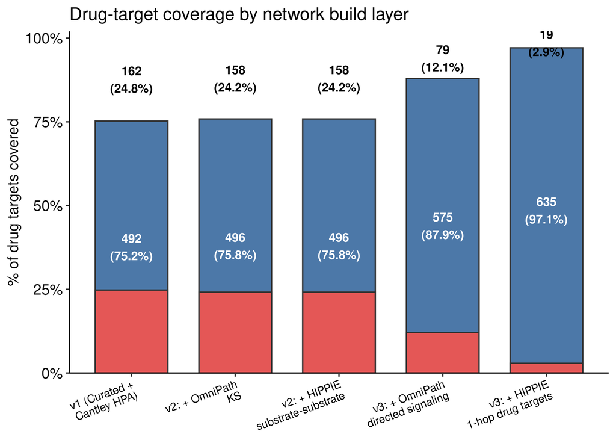

```r
# Layer-by-layer build for v3
nodes_after_ks      <- union(as.character(combined_with_omnipath$Kinase_entrez),
                              as.character(combined_with_omnipath$Substrate_entrez))
nodes_after_hippie  <- union(nodes_after_ks,
                              c(hippie_ss_final$Protein1_entrez, hippie_ss_final$Protein2_entrez))
nodes_after_op_sig  <- union(nodes_after_hippie,
                              c(op_c_phase1_final$Protein1_entrez, op_c_phase1_final$Protein2_entrez))
nodes_after_hippie2 <- union(nodes_after_op_sig,
                              c(hippie_c_phase2_final$Protein1_entrez, hippie_c_phase2_final$Protein2_entrez))

layer_cov <- tibble(
  label    = c("v1 (Curated +\nCantley HPA)",
               "v2: + OmniPath\nKS",
               "v2: + HIPPIE\nsubstrate-substrate",
               "v3: + OmniPath\ndirected signaling",
               "v3: + HIPPIE\n1-hop drug targets"),
  covered  = c(cov_v1,
               sum(drug_ids %in% nodes_after_ks),
               sum(drug_ids %in% nodes_after_hippie),
               sum(drug_ids %in% nodes_after_op_sig),
               sum(drug_ids %in% nodes_after_hippie2))
) %>%
  mutate(
    missing  = n_drugs - covered,
    pct      = 100 * covered / n_drugs,
    label    = fct_inorder(label)
  )

ggplot(layer_cov, aes(x = label)) +
  geom_col(aes(y = pct),       fill = "#4C78A8", color = "grey20", width = 0.7) +
  geom_col(aes(y = 100 - pct), fill = "#E45756", color = "grey20", width = 0.7,
           position = position_stack(reverse = FALSE)) +
  geom_text(aes(y = pct / 2,
                label = paste0(covered, "\n(", round(pct, 1), "%)")),
            color = "white", fontface = "bold", size = 3.5) +
  geom_text(aes(y = pct + (100 - pct) / 2,
                label = paste0(missing, "\n(", round(100 - pct, 1), "%)")),
            fontface = "bold", size = 3.5) +
  scale_y_continuous(labels = function(x) paste0(x, "%"),
                     limits = c(0, 101), expand = expansion(mult = c(0, 0.01))) +
  labs(x = NULL, y = "% of drug targets covered",
       title = "Drug-target coverage by network build layer") +
  theme_pubr(x.text.angle = 20) +
  theme(axis.text.x = element_text(size = 9))
```

# Source Composition

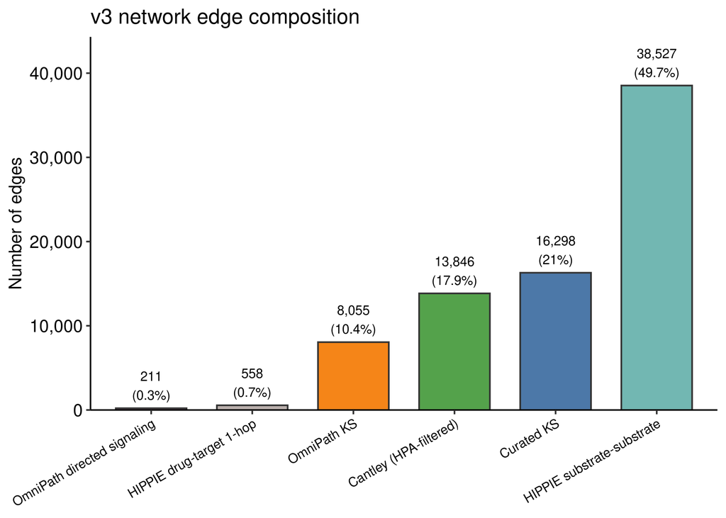

```r
edge_sources <- full_network_v3 %>%
  mutate(Source_clean = case_when(
    Source %in% c("PhosphoSitePlus", "EPSD", "iPTMNet",
                  "PhosphoNetworks", "PhosphoELM") ~ "Curated KS",
    Source == "Cantley"            ~ "Cantley (HPA-filtered)",
    Source == "OmniPath"           ~ "OmniPath KS",
    Source == "HIPPIE"             ~ "HIPPIE substrate-substrate",
    Source == "OmniPath_Signaling" ~ "OmniPath directed signaling",
    Source == "HIPPIE_DrugTarget"  ~ "HIPPIE drug-target 1-hop",
    TRUE ~ Source
  )) %>%
  count(Source_clean) %>%
  mutate(pct = 100 * n / sum(n),
         Source_clean = fct_reorder(Source_clean, n))

ggplot(edge_sources, aes(x = Source_clean, y = n, fill = Source_clean)) +
  geom_col(color = "grey20", width = 0.7, show.legend = FALSE) +
  geom_text(aes(label = paste0(comma(n), "\n(", round(pct, 1), "%)")),
            vjust = -0.3, size = 3.2) +
  scale_fill_manual(values = c(
    "Curated KS"                    = "#4C78A8",
    "Cantley (HPA-filtered)"        = "#54A24B",
    "OmniPath KS"                   = "#F58518",
    "HIPPIE substrate-substrate"    = "#72B7B2",
    "OmniPath directed signaling"   = "#B279A2",
    "HIPPIE drug-target 1-hop"      = "#BAB0AC"
  )) +
  scale_y_continuous(labels = comma, expand = expansion(mult = c(0, 0.15))) +
  labs(x = NULL, y = "Number of edges",
       title = "v3 network edge composition") +
  theme_pubr(x.text.angle = 30) +
  theme(axis.text.x = element_text(size = 9))
```

# v1 vs v2 vs v3 Comparison

```r
compare_df <- tibble(
  version = c("v1", "v2 conservative", "v3 (Strategy C)"),
  edges   = c(nrow(network_v1), nrow(network_v2), nrow(full_network_v3_summary)),
  nodes   = c(length(nodes_v1), length(nodes_v2), length(nodes_v3)),
  drug_cov = c(cov_v1, cov_v2, cov_v3),
  drug_pct = round(100 * c(cov_v1, cov_v2, cov_v3) / n_drugs, 1)
)

cat("=== Version Comparison ===\n")
```

```
=== Version Comparison ===
```

```r
print(compare_df)
```

```
# A tibble: 3 × 5
  version         edges nodes drug_cov drug_pct
  <chr>           <int> <int>    <int>    <dbl>
1 v1              50583  4713      492     75.2
2 v2 conservative 61055  4917      611     93.4
3 v3 (Strategy C) 61710  4941      635     97.1
```

```r
# v3 new drug targets vs v2 (check isolation)
v3_drug_targets_entrez <- drug_ids[drug_ids %in% nodes_v3]
v3_new_vs_v2 <- drug_ids[drug_ids %in% nodes_v3 & !drug_ids %in% nodes_v2]
cat("\nNew targets in v3 vs v2:", length(v3_new_vs_v2), "\n")
```

```
New targets in v3 vs v2: 24
```

```r
# Strategy C expansion in v3
cat("\nStrategy C layer breakdown in v3:\n")
```

```
Strategy C layer breakdown in v3:
```

```r
cat("  OmniPath directed signaling edges:     ", nrow(op_c_phase1_final), "\n")
```

```
  OmniPath directed signaling edges:      211
```

```r
cat("  HIPPIE 1-hop drug-target edges:         ", nrow(hippie_c_phase2_final), "\n")
```

```
  HIPPIE 1-hop drug-target edges:          558
```

```r
cat("  Total strategy C edges:                ", nrow(op_c_phase1_final) + nrow(hippie_c_phase2_final), "\n")
```

```
  Total strategy C edges:                 769
```

```r
cat("\nvs v2 brute-force: 114 edges (all degree-1)\n")
```

```
vs v2 brute-force: 114 edges (all degree-1)
```